# LDL cholesterol

# 1 Description of DataSchema variable

The description of harmonised variables is the following:

- Short name: `ldl_chol`
- Variable label: `Serum LDL Cholesterol`
- Variable description: `Serum LDL Cholesterol (mg/dl)`
- Domain: `Laboratory measures`
- Value type: `continuous`
- Category missings:

| **Code** | **Category Label** |
| --- | --- |
| 991 | CAPI/interviewer error |
| 992 | Impute |
| 993 | Disable to measure |
| 994 | Not attempt/not done |
| 995 | Does not answer |
| 996 | Not applicable |
| 997 | Refuse |
| 998 | Do not know |
| 999 | Missing |

# 2 Data process

## 2.1 England

### 2.1.1 Wave 1

Not found.

### 2.1.2 Wave 2

#### 2.1.2.1 Study-specific variable description

| **Name** | `ldl` |
| --- | --- |
| **Label** | `Blood LDL level (mmol/l)` |
| **Table name** | `wave_2_nurse_data_v2` |
| **Categories:** | `continuous` |
| **Missings:** | `-11 = Blood sample not taken` `-7 = Sample unusable (for other reason)` `-6 = Period between collection and receipt in the lab > 5 days` `-5 = Unable to calculate the result as TRIG value >4.5mmol/L`… |
| **Description** |  |

ldl

| Sample size | Missing values |
| --- | --- |
| 7666 | 1924 |

Summary

| Min. | 1st Qu. | Median | Mean | 3rd Qu. | Max. |
| --- | --- | --- | --- | --- | --- |
| 0.4 | 2.9 | 3.6 | 3.586 | 4.2 | 9.2 |

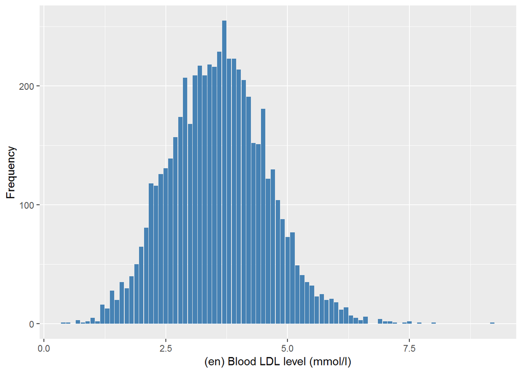

#### 2.1.2.2 Harmonisation algorithm

To compute `ldl_chol` from the study-specific variable it has to be recoded as follows:

- `multiply mmol/L by 38.67`
- `-11 into 994`
- `-7 into 993`
- `-6 into 993`
- `-5 into 993`
- `-3 into 993`
- `-2 into 993`
- `-1 into 999`

**R script:**

```r
ELSA_ds_w2 <- tibble(id = ELSA_w2$id)
ELSA_ds_w2$ldl_chol <- car::recode(ELSA_w2$ldl, "-11 = 994;-8:-2 = 993; -1 = 999")
ELSA_ds_w2$ldl_chol[which(!ELSA_ds_w2$ldl_chol %in% miss_values_vector)] <- 38.67 *
    ELSA_ds_w2$ldl_chol[which(!ELSA_ds_w2$ldl_chol %in% miss_values_vector)]
```

#### 2.1.2.3 Statistical description of the new harmonised variable

Serum LDL Cholesterol

| Sample size | Missing values |
| --- | --- |
| 7666 | 1924 |

Values

|  | No-missings | 991 | 992 | 993 | 994 | 995 | 996 | 997 | 998 | 999 | NA |
| --- | --- | --- | --- | --- | --- | --- | --- | --- | --- | --- | --- |
| Frequency | 5742.0 | 0 | 0 | 440.00 | 1435.00 | 0 | 0 | 0 | 0 | 49.00 | 0 |
| Percentage | 74.9 | 0 | 0 | 5.74 | 18.72 | 0 | 0 | 0 | 0 | 0.64 | 0 |

Summary

| Min. | 1st Qu. | Median | Mean | 3rd Qu. | Max. |
| --- | --- | --- | --- | --- | --- |
| 15.47 | 112.1 | 139.2 | 138.7 | 162.4 | 355.8 |

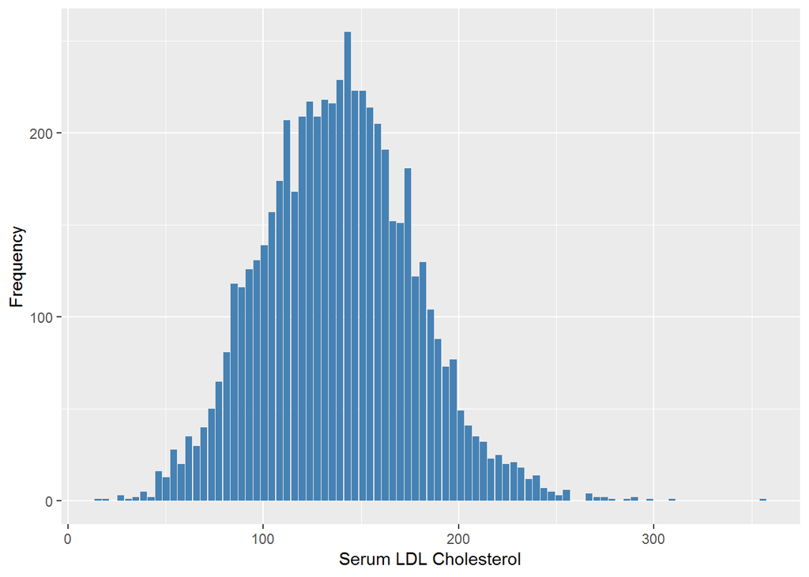

#### 2.1.2.4 Validation

### 2.1.3 Wave 3

Not found

### 2.1.4 Wave 4

#### 2.1.4.1 Study-specific variable description

| **Name** | `ldl` |
| --- | --- |
| **Label** | `Blood LDL level (mmol/l)` |
| **Table name** | `wave_4_nurse_data` |
| **Categories:** | `continuous` |
| **Missings:** | `-11 = Blood sample not taken` `-6 = Sample took more than five days to reach the lab so is unsuitable for analysis` `-5 = Indicates that triglyceride measurement is unreliable` `-3 = Sample received … |
| **Description** |  |

ldl

| Sample size | Missing values |
| --- | --- |
| 8643 | 2346 |

Summary

| Min. | 1st Qu. | Median | Mean | 3rd Qu. | Max. |
| --- | --- | --- | --- | --- | --- |
| 0.4 | 2.6 | 3.2 | 3.274 | 4 | 8 |

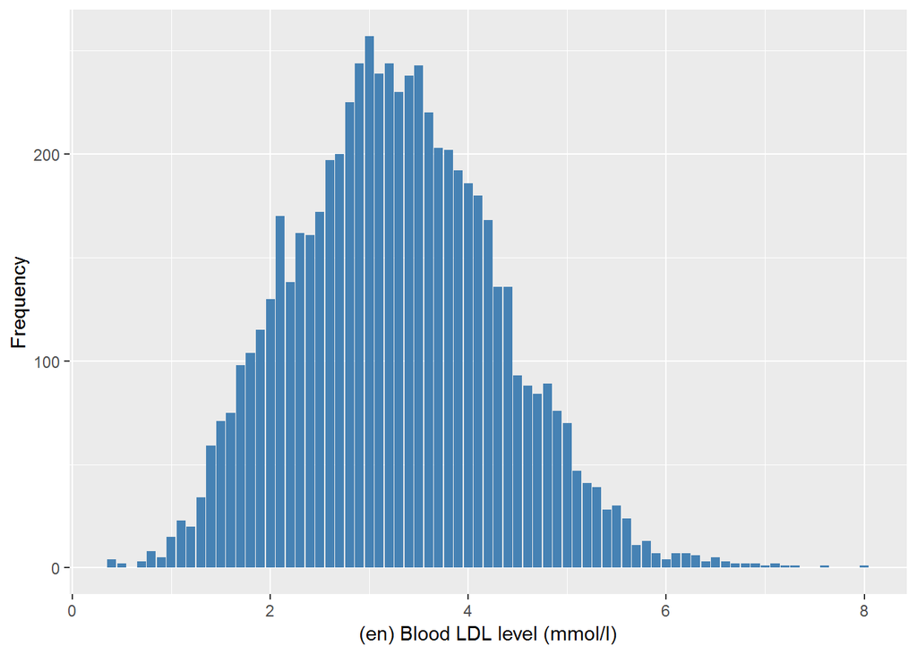

#### 2.1.4.2 Harmonisation algorithm

To compute `ldl_chol` from the study-specific variable it has to be recoded as follows:

- `multiply mmol/L by 38.67`
- `-11 into 994`
- `-6 into 993`
- `-5 into 993`
- `-3 into 993`
- `-2 into 993`
- `-1 into 999`

**R script:**

```r
ELSA_ds_w4 <- tibble(id = ELSA_w4$id)
ELSA_ds_w4$ldl_chol <- car::recode(ELSA_w4$ldl, "-11 = 994;-7:-2 = 993; -1 = 999")
ELSA_ds_w4$ldl_chol[which(!ELSA_ds_w4$ldl_chol %in% miss_values_vector)] <- 38.67 *
    ELSA_ds_w4$ldl_chol[which(!ELSA_ds_w4$ldl_chol %in% miss_values_vector)]
```

#### 2.1.4.3 Statistical description of the new harmonised variable

Serum LDL Cholesterol

| Sample size | Missing values |
| --- | --- |
| 8643 | 2346 |

Values

|  | No-missings | 991 | 992 | 993 | 994 | 995 | 996 | 997 | 998 | 999 | NA |
| --- | --- | --- | --- | --- | --- | --- | --- | --- | --- | --- | --- |
| Frequency | 6297.00 | 0 | 0 | 400.00 | 1863.00 | 0 | 0 | 0 | 0 | 83.00 | 0 |
| Percentage | 72.86 | 0 | 0 | 4.63 | 21.56 | 0 | 0 | 0 | 0 | 0.96 | 0 |

Summary

| Min. | 1st Qu. | Median | Mean | 3rd Qu. | Max. |
| --- | --- | --- | --- | --- | --- |
| 15.47 | 100.5 | 123.7 | 126.6 | 154.7 | 309.4 |

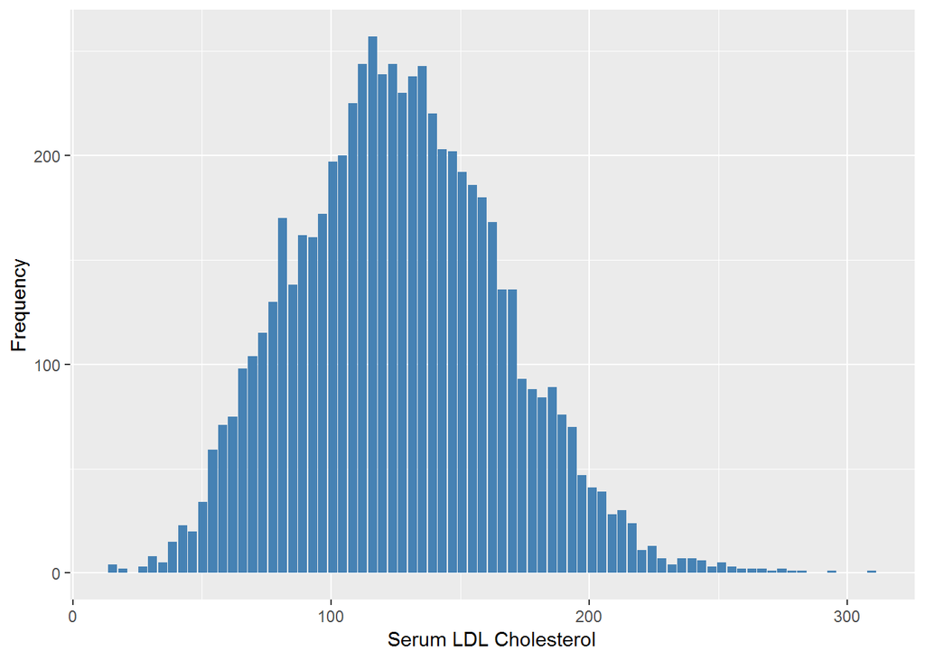

#### 2.1.4.4 Validation

### 2.1.5 Wave 5

Not found

### 2.1.6 Wave 6

#### 2.1.6.1 Study-specific variable description

| **Name** | `ldl` |
| --- | --- |
| **Label** | `Blood LDL level (mmol/l)` |
| **Table name** | `wave_6_elsa_nurse_data_v2` |
| **Categories:** | `continuous` |
| **Missings:** | `-6 = Sample took more than five days to reach the lab so is unsuitable for analysis` `-5 = Indicates that triglyceride measurement is unreliable` `-3 = Sample received but was haemolysed and so not s… |
| **Description** |  |

ldl

| Sample size | Missing values |
| --- | --- |
| 8054 | 2000 |

Summary

| Min. | 1st Qu. | Median | Mean | 3rd Qu. | Max. |
| --- | --- | --- | --- | --- | --- |
| 0.4 | 2.4 | 3.2 | 3.216 | 3.9 | 7.6 |

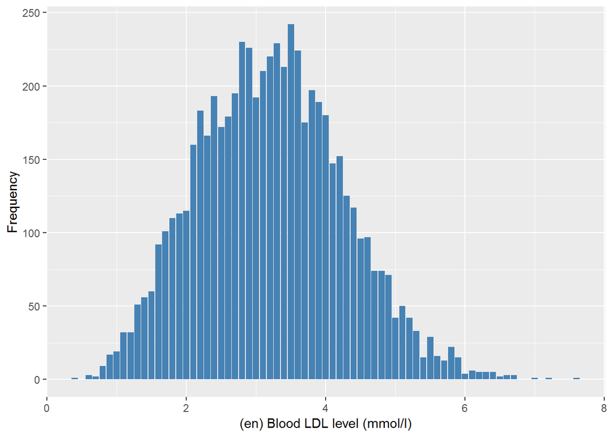

#### 2.1.6.2 Harmonisation algorithm

To compute `ldl_chol` from the study-specific variable it has to be recoded as follows:

- `multiply mmol/L by 38.67`
- `-6 into 993`
- `-5 into 993`
- `-3 into 993`
- `-2 into 993`
- `-1 into 999`

**R script:**

```r
ELSA_ds_w6 <- tibble(id = ELSA_w6$id)
ELSA_ds_w6$ldl_chol <- car::recode(ELSA_w6$ldl, "-11 = 994; -7:-2 = 993; -1 = 999")
ELSA_ds_w6$ldl_chol[which(!ELSA_ds_w6$ldl_chol %in% miss_values_vector)] <- 38.67 *
    ELSA_ds_w6$ldl_chol[which(!ELSA_ds_w6$ldl_chol %in% miss_values_vector)]
```

#### 2.1.6.3 Statistical description of the new harmonised variable

Serum LDL Cholesterol

| Sample size | Missing values |
| --- | --- |
| 8054 | 2000 |

Values

|  | No-missings | 991 | 992 | 993 | 994 | 995 | 996 | 997 | 998 | 999 | NA |
| --- | --- | --- | --- | --- | --- | --- | --- | --- | --- | --- | --- |
| Frequency | 6054.00 | 0 | 0 | 328.00 | 0 | 0 | 0 | 0 | 0 | 1672.00 | 0 |
| Percentage | 75.17 | 0 | 0 | 4.07 | 0 | 0 | 0 | 0 | 0 | 20.76 | 0 |

Summary

| Min. | 1st Qu. | Median | Mean | 3rd Qu. | Max. |
| --- | --- | --- | --- | --- | --- |
| 15.47 | 92.81 | 123.7 | 124.4 | 150.8 | 293.9 |

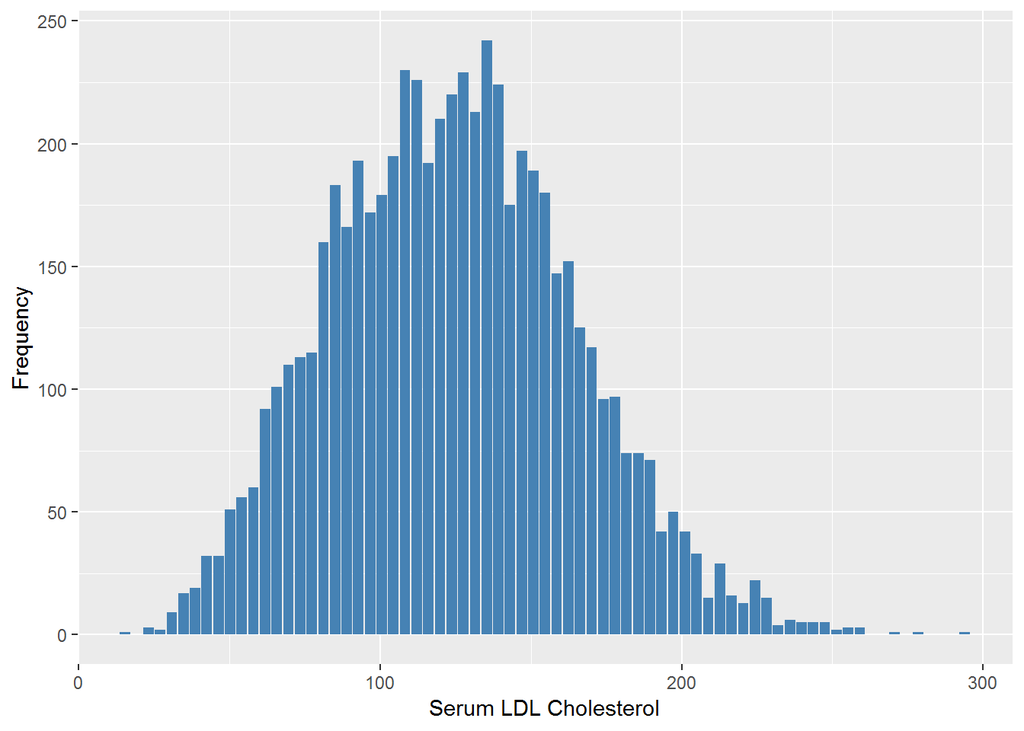

#### 2.1.6.4 Validation

### 2.1.7 Wave 7

Not found

## 2.2 Summary of descriptive statistics of the harmonised variable accross populations and waves

```r
l.hds <- list(w2 = ELSA_ds_w2, w4 = ELSA_ds_w4, w6 = ELSA_ds_w6)
m.hds <- list()

for (name in names(l.hds)) {
    aux_object <- l.hds[[name]]
    label(l.hds[[name]][[2]]) <- label(aux_object[[2]]) <- ds_label  # Text value assigned at the DS description, at the top
    l.hds[[name]][[2]] <- labelled(l.hds[[name]][[2]], labels = cont_label)
    aux_object[[2]] <- car::recode(aux_object[[2]], "miss_values_vector=NA")
    aux_object[[2]] <- labelled(aux_object[[2]], labels = cont_label)
    m_name <- paste0("ELSA_m_ds_", name)
    assign(m_name, aux_object)
    m.hds[[name]] <- get(paste0("ELSA_m_ds_", name))
    rm(aux_object)
}

t.summ <- summary(m.hds[[1]][2])[1:6]
t.hds <- substr(t.summ, 1, regexpr(":", t.summ, fixed = T) - 1)
for (i in seq_along(l.hds)) {
    t.summ <- summary(m.hds[[i]][2])[1:6]
    t.hds <- cbind(t.hds, as.numeric(substr(t.summ, regexpr(":", t.summ, fixed = T) +
        1, nchar(t.summ))))
}
t.hds <- rbind(t.hds, c("sample size", sapply(l.hds, function(wave) length(wave[[1]]))))

dimnames(t.hds)[[2]] <- c(dimnames(summary(m.hds[[1]][2]))[[2]], names(l.hds))
kable(t.hds)
```

| ldl_chol | w2 | w4 | w6 |
| --- | --- | --- | --- |
| Min. | 15.47 | 15.47 | 15.47 |
| 1st Qu. | 112.14 | 100.54 | 92.81 |
| Median | 139.21 | 123.74 | 123.74 |
| Mean | 138.68 | 126.6 | 124.35 |
| 3rd Qu. | 162.41 | 154.68 | 150.81 |
| Max. | 355.76 | 309.36 | 293.89 |
| sample size | 7666 | 8643 | 8054 |

# 3 Quality estimation